# Group2.Rmd

Tamar Yastrab & Hasanat Jahan

6/23/2020

We reproduced the findings in Predicting the Present with Google Trends with both author provided data and data we gathered independently http://people.ischool.berkeley.edu/~hal/Papers/2011/ptp.pdf

## R Markdown

```r
library(tidyverse)
library(scales)
library(modelr)
library(lubridate)
library(dplyr)
```

# Reproduce the findings based on author-provided data

Read in the given data

```r
mvp <- read.csv("merged.csv", header=T) %>% mutate(last_month = lag(sales), last_year = lag(sales, 12)) %>% mutate(row_num = row_number()) %>% mutate(log_sales = log(sales)) %>% mutate(ymd = as.Date(Period, "%Y/%m/%d"))
```

We created 2 models for the mvp data. The first only considers the previous month and the same month one year prior, and the second considers additional factors (insurance, suvs) provided by the trends data.

```r
mvp_base_model <- lm(sales ~ last_month + last_year,  data=mvp)
summary(mvp_base_model)
```

```
##
## Call:
## lm(formula = sales ~ last_month + last_year, data = mvp)
##
## Residuals:
##      Min       1Q   Median       3Q      Max
## -12076.7  -2927.3    291.7   2828.1  13188.1
##
## Coefficients:
##              Estimate Std. Error t value Pr(>|t|)
## (Intercept) 3.572e+03  4.729e+03   0.755    0.452
## last_month  6.140e-01  7.391e-02   8.308 2.83e-12 ***
## last_year   3.287e-01  7.347e-02   4.473 2.66e-05 ***
## ---
## Signif. codes:  0 '***' 0.001 '**' 0.01 '*' 0.05 '.' 0.1 ' ' 1
##
## Residual standard error: 5301 on 76 degrees of freedom
##   (12 observations deleted due to missingness)
## Multiple R-squared:  0.7197, Adjusted R-squared:  0.7124
## F-statistic: 97.59 on 2 and 76 DF,  p-value: < 2.2e-16
```

```r
mvp_trends_model <- lm(sales ~ last_month + last_year + suvs + insurance,  data=mvp)
summary(mvp_trends_model)
```

```
##
## Call:
## lm(formula = sales ~ last_month + last_year + suvs + insurance,
##     data = mvp)
##
## Residuals:
##    Min     1Q Median     3Q    Max
##  -9790  -2998     51   2732   9051
##
## Coefficients:
##               Estimate Std. Error t value Pr(>|t|)
## (Intercept)  1.966e+03  5.671e+03   0.347  0.72979
## last_month   5.858e-01  6.341e-02   9.238 5.92e-14 ***
## last_year    4.653e-01  6.538e-02   7.116 5.96e-10 ***
## suvs         7.176e+04  1.102e+04   6.514 7.81e-09 ***
## insurance   -3.443e+04  1.011e+04  -3.406  0.00107 **
## ---
## Signif. codes:  0 '***' 0.001 '**' 0.01 '*' 0.05 '.' 0.1 ' ' 1
##
## Residual standard error: 4281 on 74 degrees of freedom
##   (12 observations deleted due to missingness)
## Multiple R-squared:  0.822,  Adjusted R-squared:  0.8124
## F-statistic: 85.42 on 4 and 74 DF,  p-value: < 2.2e-16
```

We created 2 vectors to keep track of the predictions made by the two models. We loop from 2005-06-01 to 2011-07-01 as indicated by the paper. For each iteration, we make a linear model that will serve as the base for a prediction and then add the prediction to the corresponding vector.

```r
base_prediction = c()
trends_prediction = c()
mae_base_prediction = c()
mae_trends_prediction = c()

K <- 17: nrow(mvp) # dates

for (k in K) {
  test_data<- mvp %>% filter(row_num <= k) # only uses previous data
  model_base <- lm(log_sales ~ last_month + last_year , data=test_data)
  model_trends <- lm(log_sales ~ last_month + last_year + suvs + insurance, data=test_data)

  base_prediction[k] <- predict(model_base, test_data)[k]
  trends_prediction[k] <- predict(model_trends, test_data)[k]

  # calculate mae for trends and baseline
  mae_base_prediction[k] <- mean(abs(predict(model_base, test_data)[k] - test_data$log_sales))
# calculate mae for trends and baseline
  mae_trends_prediction[k] <- mean(abs(predict(model_trends, test_data)[k] - test_data$log_sales))

}
```

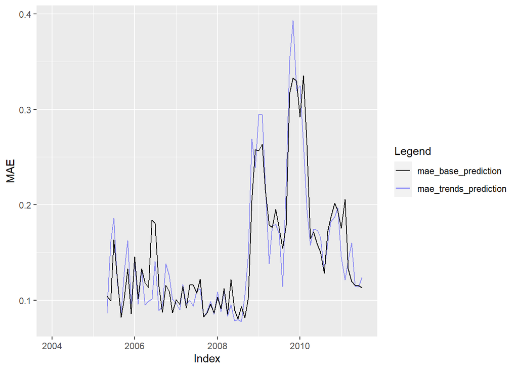

```r
mae_data <- data.frame(mae_base_prediction, mae_trends_prediction) %>%
  na.omit(mae_base_prediction) %>% mutate(row_num = row_number() + 16)

mae_total <- mvp %>% left_join(mae_data, by = "row_num")

colors <- c("mae_trends_prediction" = "blue", "mae_base_prediction" = "black")

ggplot(mae_total, aes(x = ymd, y = mae_base_prediction)) +
  geom_line() +
  geom_line(aes(y = mae_trends_prediction, color = "mae_trends_prediction"), alpha= 0.4) +
  geom_line(aes(y = mae_base_prediction, color="mae_base_prediction")) +
  labs(x= 'Index', y ='MAE',color = "Legend") +
  scale_color_manual(values=colors) +
  scale_y_continuous()
```

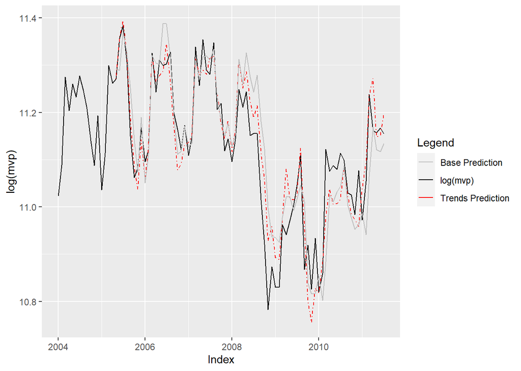

```r
prediction_data <- data.frame(base_prediction, trends_prediction) %>% na.omit(base_prediction) %>% mutate(row_num = row_number() + 16)

total <- mvp %>% left_join(prediction_data, by = "row_num")

pred_colors = c("Trends Prediction" = "red", "Base Prediction" = "grey", "log(mvp)"= "black")
ggplot(total, aes(x = ymd, y = log_sales)) +
  geom_line(aes(color = "log(mvp)")) +
  geom_line(aes(y = trends_prediction, color = "Trends Prediction"), linetype = "dotdash") +
  geom_line(aes(y = base_prediction, color="Base Prediction")) +
  labs(x='Index',
       y='log(mvp)',
       color="Legend") +
  scale_color_manual(values = pred_colors) +
  scale_y_continuous()
```

# Getting the Data from their original locations

Rather than just take the author-provided data, we wanted to get the data ourselves from the Census Bureau and Google Trends. We cleaned the data and joined the mvp data together with the trends data just like we did above. The rest of the code is identical but with the new data.

```r
#real_base <- read_tsv("base_mvp.tsv") %>% filter(JAN >= 60000)
real_trends_mvp <- left_join(read.csv("real_trends_insurance.csv", header = T),
                         read.csv("real_trends_trucks.csv", header = T),
                         by = "Month") %>%
  rename("insurance" = Geo..United.States.x, "suvs" = Geo..United.States.y) %>%
  mutate(ymd2 = paste(Month, "-01", sep="")) %>%
  mutate(ymd = as.Date(ymd2, "%Y-%m-%d")) %>%
  select(ymd, insurance, suvs)

real_base_mvp <- read.csv("real_base_autos.csv") %>%
  mutate(ymd2 = paste(Period, "-01", sep="")) %>%
  mutate(ymd = as.Date(ymd2, "%b-%y-%d")) %>% select(ymd, Value)

real_mvp <- left_join(real_trends_mvp, real_base_mvp, by = "ymd") %>% mutate(last_month = lag(Value), last_year = lag(Value, 12)) %>% mutate(row_num = row_number()) %>% mutate(log_sales = log(Value))
```

```r
real_base_model <- lm(Value ~ last_month + last_year,  data=real_mvp)
summary(real_base_model)
```

```
##
## Call:
## lm(formula = Value ~ last_month + last_year, data = real_mvp)
##
## Residuals:
##      Min       1Q   Median       3Q      Max
## -11975.6  -2915.2    318.5   2807.9  13346.9
##
## Coefficients:
##              Estimate Std. Error t value Pr(>|t|)
## (Intercept) 3.513e+03  4.692e+03   0.749    0.456
## last_month  6.209e-01  7.349e-02   8.449 1.52e-12 ***
## last_year   3.223e-01  7.298e-02   4.416 3.28e-05 ***
## ---
## Signif. codes:  0 '***' 0.001 '**' 0.01 '*' 0.05 '.' 0.1 ' ' 1
##
## Residual standard error: 5301 on 76 degrees of freedom
##   (12 observations deleted due to missingness)
## Multiple R-squared:  0.7223, Adjusted R-squared:  0.715
## F-statistic: 98.85 on 2 and 76 DF,  p-value: < 2.2e-16
```

```r
real_trends_model <- lm(Value ~ last_month + last_year + suvs + insurance,  data=real_mvp)
summary(real_trends_model)
```

```
##
## Call:
## lm(formula = Value ~ last_month + last_year + suvs + insurance,
##     data = real_mvp)
##
## Residuals:
##      Min       1Q   Median       3Q      Max
## -11213.9  -2894.2   -185.4   2526.1  13778.4
##
## Coefficients:
##               Estimate Std. Error t value Pr(>|t|)
## (Intercept) -1.468e+04  6.654e+03  -2.206  0.03051 *
## last_month   5.171e-01  7.977e-02   6.482 8.95e-09 ***
## last_year    3.407e-01  7.064e-02   4.822 7.40e-06 ***
## suvs         7.076e+02  1.643e+02   4.308 5.00e-05 ***
## insurance   -4.055e+02  1.312e+02  -3.092  0.00281 **
## ---
## Signif. codes:  0 '***' 0.001 '**' 0.01 '*' 0.05 '.' 0.1 ' ' 1
##
## Residual standard error: 4692 on 74 degrees of freedom
##   (12 observations deleted due to missingness)
## Multiple R-squared:  0.7882, Adjusted R-squared:  0.7767
## F-statistic: 68.84 on 4 and 74 DF,  p-value: < 2.2e-16
```

```r
real_base_prediction = c()
real_trends_prediction = c()
real_mae_base_prediction = c()
real_mae_trends_prediction = c()

K <- 17: nrow(real_mvp) # dates

for (k in K) {
  test_data<- real_mvp %>% filter(row_num <= k) # only uses previous data
  model_base <- lm(log_sales ~ last_month + last_year , data=test_data)
  model_trends <- lm(log_sales ~ last_month + last_year + suvs + insurance, data=test_data)

  real_base_prediction[k] <- predict(model_base, test_data)[k]
  real_trends_prediction[k] <- predict(model_trends, test_data)[k]

  real_mae_base_prediction[k] <- mean(abs(predict(model_base, test_data)[k] - test_data$log_sales))
  real_mae_trends_prediction[k] <- mean(abs(predict(model_trends, test_data)[k] - test_data$log_sales))

}
```

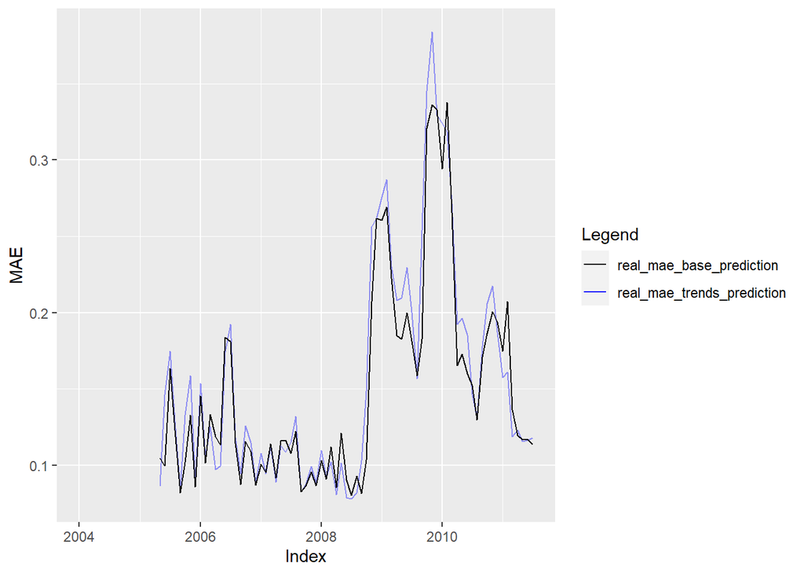

```r
real_mae_data <- data.frame(real_mae_base_prediction, real_mae_trends_prediction) %>%
  na.omit(real_mae_base_prediction) %>% mutate(row_num = row_number() + 16)

real_mae_total <- real_mvp %>% left_join(real_mae_data, by = "row_num")

colors <- c("real_mae_trends_prediction" = "blue", "real_mae_base_prediction" = "black")

ggplot(real_mae_total, aes(x = ymd, y = real_mae_base_prediction)) +
  geom_line() +
  geom_line(aes(y = real_mae_trends_prediction, color = "real_mae_trends_prediction"), alpha= 0.4) +
  geom_line(aes(y = real_mae_base_prediction, color="real_mae_base_prediction")) +
  labs(x= 'Index', y ='MAE',color = "Legend") +
  scale_color_manual(values=colors) +
  scale_y_continuous()
```

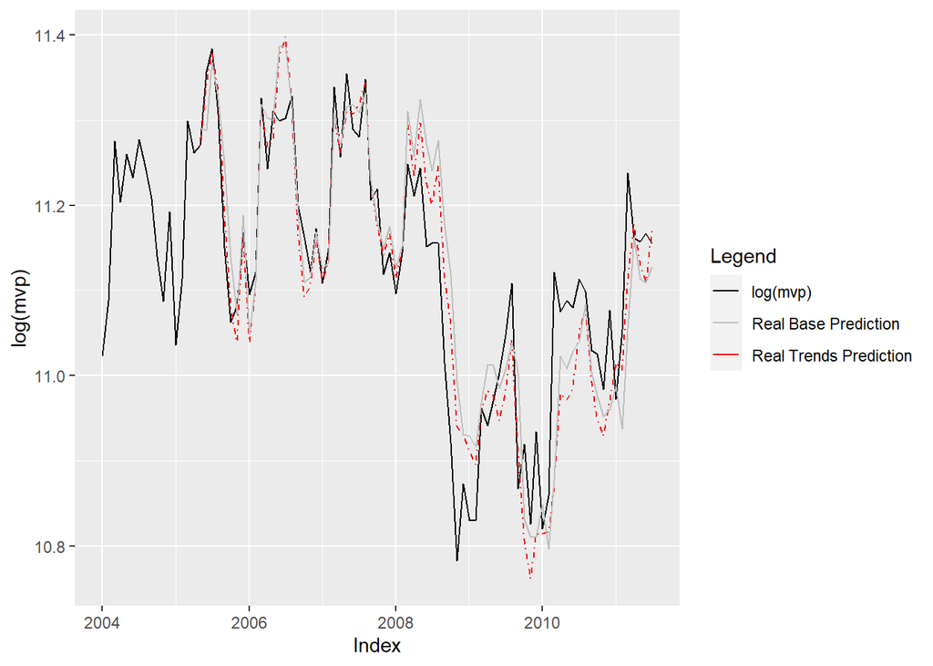

```r
real_prediction_data <- data.frame(real_base_prediction, real_trends_prediction) %>% na.omit(real_base_prediction) %>% mutate(row_num = row_number() + 16)

real_total <- real_mvp %>% left_join(real_prediction_data, by = "row_num")

pred_colors = c("Real Trends Prediction" = "red", "Real Base Prediction" = "grey", "log(mvp)"= "black")
ggplot(total, aes(x = ymd, y = log_sales)) +
  geom_line(aes(color = "log(mvp)")) +
  geom_line(aes(y = real_trends_prediction, color = "Real Trends Prediction"), linetype = "dotdash") +
  geom_line(aes(y = real_base_prediction, color="Real Base Prediction")) +
  labs(x='Index',
       y='log(mvp)',
       color="Legend") +
  scale_color_manual(values = pred_colors) +
  scale_y_continuous()
```